# Projekt 1 - Statystyczna analiza danych

Klaudia Rajca, Aleksandra Konopelska

2025-10-17

# 1 ETAP I: Przygotowanie danych do projektu

## 1.1 Temat projektu: Ocena poziomu rozwoju społeczno-gospodarczego państw świata

Celem projektu jest przeprowadzenie analizy porównawczej krajów świata pod względem wybranych wskaźników społeczno-ekonomicznych. Dane obejmują wybrane wskaźniki społeczno-ekonomiczne, takie jak PKB per capita, poziom alfabetyzacji, liczba telefonów, śmiertelność niemowląt, współczynnik urodzeń, udział przemysłu i usług w PKB oraz klimat. Analiza obejmuje dwa etapy: porządkowanie liniowe oraz analizę skupień. W ramach porządkowania liniowego zostanie utworzony ranking krajów w oparciu o syntetyczny miernik rozwoju, natomiast analiza skupień pozwoli na identyfikację grup państw o podobnym poziomie rozwoju.

## 1.2 Źródło danych

Dane pochodzą z pliku “countries of the world.csv”, opracowanego na podstawie źródeł rządowych USA (US Government), obejmujących lata 1970–2017. Oznacza to, że dane nie dotyczą jednego konkretnego roku, lecz stanowią zestaw uśrednionych i orientacyjnych wskaźników opisujących sytuację społeczno-gospodarczą poszczególnych państw. W analizie przyjmujemy je jako dane przekrojowe (pozwalają na porównanie krajów między sobą w jednym momencie, nie analizując zmian w czasie), co umożliwia ich wykorzystanie w metodach statystycznych, takich jak porządkowanie liniowe i analiza skupień.

## 1.3 Porządkowanie liniowe i Analiza skupień

Porządkowanie liniowe to metoda, która na podstawie różnych cech przypisuje obiektom kolejność, tworząc ranking, np. od najlepszego do najgorszego. Analiza skupień natomiast grupuje obiekty w zbiory (skupienia) na podstawie ich podobieństwa, tak aby obiekty w jednym skupieniu były do siebie jak najbardziej podobne, a różniły się od obiektów z innych skupień. Chociaż obu metod można używać do klasyfikacji, porządkowanie liniowe tworzy jedną oś, podczas gdy analiza skupień tworzy wiele grup.

## 1.4 Wykorzystywane pakiety R

Pakiety, które będą użyte w analizie:

```r
library(dplyr)
library(ggplot2)
library(readr)
library(tidyr)
library(scales)
library(corrplot)
library(factoextra)
library(RColorBrewer)
```

## 1.5 Wczytanie danych

```r
dane <- read.csv("countries of the world.csv", sep = ",", stringsAsFactors = FALSE)
```

## 1.6 Podgląd pierwszych wierszy danych

```r
head(dane)
```

```
##           Country                              Region Population Area..sq..mi..
## 1    Afghanistan        ASIA (EX. NEAR EAST)            31056997         647500
## 2        Albania  EASTERN EUROPE                         3581655          28748
## 3        Algeria  NORTHERN AFRICA                       32930091        2381740
## 4 American Samoa  OCEANIA                                  57794            199
## 5        Andorra  WESTERN EUROPE                           71201            468
## 6         Angola  SUB-SAHARAN AFRICA                    12127071        1246700
##   Pop..Density..per.sq..mi.. Coastline..coast.area.ratio. Net.migration
## 1                       48,0                         0,00         23,06
## 2                      124,6                         1,26         -4,93
## 3                       13,8                         0,04         -0,39
## 4                      290,4                        58,29        -20,71
## 5                      152,1                         0,00           6,6
## 6                        9,7                         0,13             0
##   Infant.mortality..per.1000.births. GDP....per.capita. Literacy....
```

[output cut: 20 more lines]

## 1.7 Przygotowanie danych

```r
# Usunięcie kolumn tekstowych (Country, Region)
if (all(c("Country", "Region") %in% names(dane))) {
  dane <- subset(dane, select = -c(Country, Region))
}


# Zamiana przecinków na kropki w kolumnach liczbowych
dane[] <- lapply(dane, function(x) {
  if (is.character(x)) as.numeric(gsub(",", ".", x)) else x
})

# Usunięcie braków danych
dane <- na.omit(dane)

# Wybór najważniejszych zmiennych ilościowych
zmienne <- c("GDP....per.capita.", "Literacy....", "Phones..per.1000.",
             "Infant.mortality..per.1000.births.", "Birthrate", "Deathrate",
             "Industry", "Service", "Climate")

dane_wybrane <- dane[intersect(zmienne, names(dane))]

# Sprawdzenie struktury danych
str(dane_wybrane)
```

```
## 'data.frame':    179 obs. of  9 variables:
##  $ GDP....per.capita.                : int  700 4500 6000 8600 11000 11200 3500 28000 29000 30000 ...
##  $ Literacy....                      : num  36 86.5 70 95 89 97.1 98.6 97 100 98 ...
##  $ Phones..per.1000.                 : num  3.2 71.2 78.1 460 549.9 ...
##  $ Infant.mortality..per.1000.births.: num  163.1 21.5 31 21 19.5 ...
##  $ Birthrate                         : num  46.6 15.1 17.1 14.2 16.9 ...
##  $ Deathrate                         : num  20.34 5.22 4.61 5.34 5.37 ...
##  $ Industry                          : num  0.24 0.188 0.6 0.18 0.22 0.358 0.343 0.333 0.262 0.304 ...
##  $ Service                           : num  0.38 0.579 0.298 0.78 0.743 0.547 0.418 0.663 0.7 0.678 ...
##  $ Climate                           : num  1 3 1 2 2 3 4 2 1 3 ...
```

# 2 ETAP II: Wstępna analiza danych

## 2.1 Podstawowe statystyki opisowe

```r
summary(dane_wybrane)
```

```
##  GDP....per.capita.  Literacy....    Phones..per.1000.
##  Min.   :  500      Min.   : 17.60   Min.   :  0.2
##  1st Qu.: 1800      1st Qu.: 69.95   1st Qu.: 27.1
##  Median : 5100      Median : 90.90   Median :137.1
##  Mean   : 9126      Mean   : 81.94   Mean   :208.2
##  3rd Qu.:12950      3rd Qu.: 97.80   3rd Qu.:335.0
##  Max.   :37800      Max.   :100.00   Max.   :898.0
##  Infant.mortality..per.1000.births.   Birthrate       Deathrate
##  Min.   :  2.29                     Min.   : 7.29   Min.   : 2.410
##  1st Qu.:  9.99                     1st Qu.:13.89   1st Qu.: 5.795
##  Median : 24.31                     Median :20.46   Median : 7.840
##  Mean   : 38.90                     Mean   :23.07   Mean   : 9.465
##  3rd Qu.: 64.61                     3rd Qu.:32.31   3rd Qu.:11.660
##  Max.   :163.07                     Max.   :50.73   Max.   :29.740
##     Industry        Service          Climate
##  Min.   :0.032   Min.   :0.0620   Min.   :1.000
##  1st Qu.:0.197   1st Qu.:0.4245   1st Qu.:2.000
##  Median :0.274   Median :0.5590   Median :2.000
##  Mean   :0.288   Mean   :0.5545   Mean   :2.109
##  3rd Qu.:0.349   3rd Qu.:0.6685   3rd Qu.:2.500
##  Max.   :0.906   Max.   :0.9540   Max.   :4.000
```

## 2.2 Wizualizacja rozkładu wybranych zmiennych

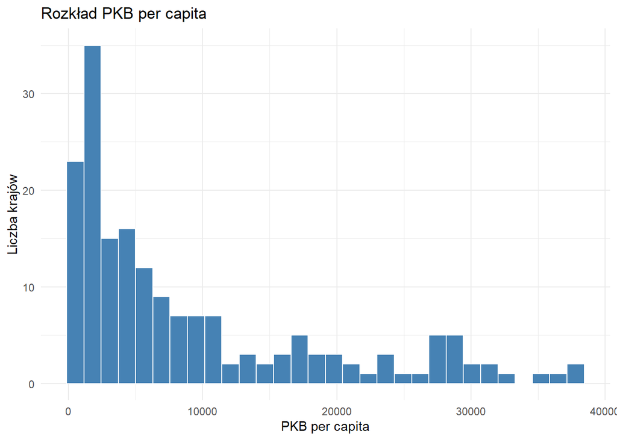

```r
# Histogram PKB per capita

ggplot(as.data.frame(dane_wybrane), aes(x = GDP....per.capita.)) +
geom_histogram(fill = "steelblue", color = "white", bins = 30) +
labs(title = "Rozkład PKB per capita",
x = "PKB per capita",
y = "Liczba krajów") +
theme_minimal()
```

Histogram PKB per capita pokazuje duże zróżnicowanie między krajami. Większość ma niski poziom dochodu, a tylko nieliczne bardzo wysoki.

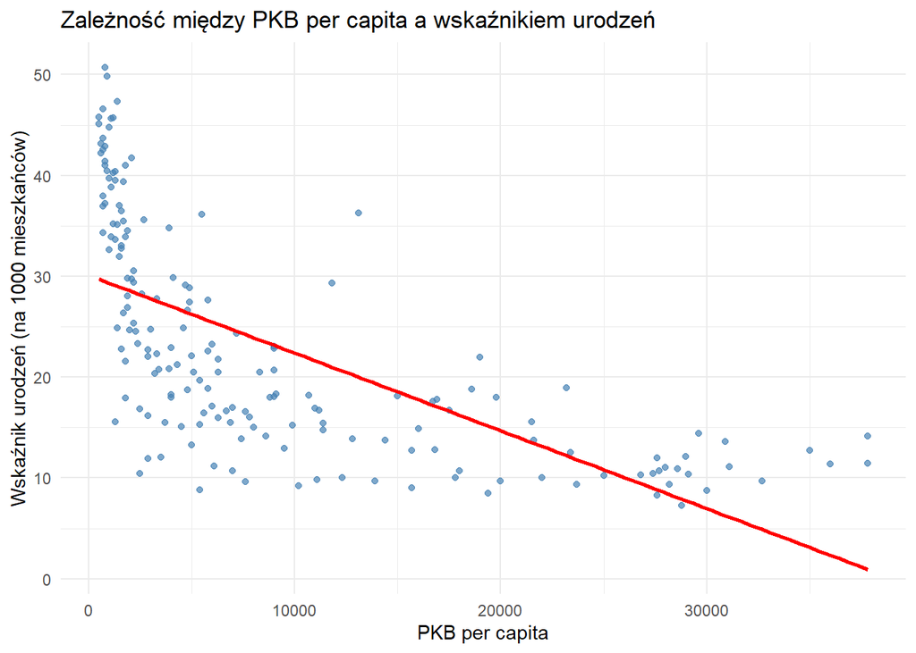

```r
# Wykres zależności między PKB a wskaźnikiem urodzeń

ggplot(as.data.frame(dane_wybrane), aes(x = GDP....per.capita., y = Birthrate)) +
geom_point(color = "steelblue", alpha = 0.7) +
geom_smooth(method = "lm", se = FALSE, color = "red") +
labs(title = "Zależność między PKB per capita a wskaźnikiem urodzeń",
x = "PKB per capita",
y = "Wskaźnik urodzeń (na 1000 mieszkańców)") +
theme_minimal()
```

Wykres zależności PKB–urodzenia wskazuje wyraźną ujemną korelację, w krajach bogatszych rodzi się mniej dzieci. Zależność ta odzwierciedla typowy wzorzec rozwoju społeczno-gospodarczego.

## 2.3 Analiza wartości odstających (outliers) przy pomocy wykresu pudełkowego (boxplot)

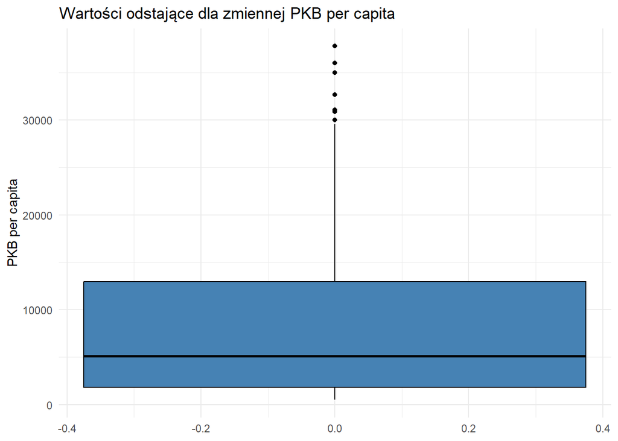

```r
ggplot(as.data.frame(dane_wybrane), aes(y = GDP....per.capita.)) +
  geom_boxplot(fill = "steelblue", color = "black") +
  labs(title = "Wartości odstające dla zmiennej PKB per capita",
       y = "PKB per capita") +
  theme_minimal()
```

Większość krajów ma niskie PKB per capita, natomiast kilka państw wysoko rozwiniętych znacząco odbiega od reszty, tworząc widoczne wartości odstające w górnej części wykresu.

## 2.4 Współczynniki zmienności (CV) przed standaryzacją

```r
cv_przed <- apply(dane_wybrane, 2, sd, na.rm = TRUE) /
             abs(apply(dane_wybrane, 2, mean, na.rm = TRUE))
round(cv_przed, 2)
```

```
##                 GDP....per.capita.                       Literacy....
##                               1.06                               0.24
##                  Phones..per.1000. Infant.mortality..per.1000.births.
##                               1.01                               0.91
##                          Birthrate                          Deathrate
##                               0.49                               0.55
##                           Industry                            Service
##                               0.49                               0.30
##                            Climate
##                               0.33
```

## 2.5 Standaryzacja danych:

## 2.6 Dane standaryzowane metodą z-score

Standaryzacja danych została przeprowadzona metodą z-score, dzięki czemu wszystkie zmienne mają średnią równą 0 i odchylenie standardowe równe 1. Dzięki temu każda zmienna ma porównywalną wagę w analizach wielowymiarowych (porządkowaniu liniowym i analizie skupień), niezależnie od jednostek czy skali pomiaru.

```r
dane_stand <- scale(dane_wybrane)

# Podsumowanie wystandaryzowanych danych
summary(dane_stand)
```

```
##  GDP....per.capita.  Literacy....     Phones..per.1000.
##  Min.   :-0.8944    Min.   :-3.2436   Min.   :-0.9897
##  1st Qu.:-0.7596    1st Qu.:-0.6046   1st Qu.:-0.8617
##  Median :-0.4174    Median : 0.4515   Median :-0.3381
##  Mean   : 0.0000    Mean   : 0.0000   Mean   : 0.0000
##  3rd Qu.: 0.3965    3rd Qu.: 0.7993   3rd Qu.: 0.6037
##  Max.   : 2.9732    Max.   : 0.9102   Max.   : 3.2831
##  Infant.mortality..per.1000.births.   Birthrate         Deathrate
##  Min.   :-1.0355                    Min.   :-1.3978   Min.   :-1.3541
##  1st Qu.:-0.8177                    1st Qu.:-0.8131   1st Qu.:-0.7044
##  Median :-0.4126                    Median :-0.2310   Median :-0.3119
##  Mean   : 0.0000                    Mean   : 0.0000   Mean   : 0.0000
##  3rd Qu.: 0.7271                    3rd Qu.: 0.8193   3rd Qu.: 0.4213
##  Max.   : 3.5123                    Max.   : 2.4508   Max.   : 3.8915
##     Industry           Service            Climate
##  Min.   :-1.82474   Min.   :-2.97283   Min.   :-1.5896
##  1st Qu.:-0.64876   1st Qu.:-0.78474   1st Qu.:-0.1562
##  Median :-0.09998   Median : 0.02711   Median :-0.1562
##  Mean   : 0.00000   Mean   : 0.00000   Mean   : 0.0000
##  3rd Qu.: 0.43455   3rd Qu.: 0.68807   3rd Qu.: 0.5606
##  Max.   : 4.40435   Max.   : 2.41137   Max.   : 2.7108
```

Wystandaryzowane dane pozwalają poprawnie interpretować zależności między zmiennymi i zapobiegają dominacji zmiennych o dużych liczbach (np. PKB per capita) nad pozostałymi.

## 2.7 Analiza korelacji:

## 2.8 Macierz korelacji (Pearsona: zależności między dwiema zmiennymi ciągłymi)

Analiza korelacji Pearsona pokazuje zależności między wskaźnikami opisującymi poziom rozwoju krajów. Dodatnia korelacja oznacza, że wartości dwóch zmiennych rosną razem, a ujemna, że wzrost jednej wiąże się ze spadkiem drugiej.

```r
macierz_korelacji <- cor(dane_stand, use = "pairwise.complete.obs", method = "pearson")
round(macierz_korelacji, 2)
```

```
##                                    GDP....per.capita. Literacy....
## GDP....per.capita.                               1.00         0.52
## Literacy....                                     0.52         1.00
## Phones..per.1000.                                0.88         0.59
## Infant.mortality..per.1000.births.              -0.64        -0.76
## Birthrate                                       -0.66        -0.79
## Deathrate                                       -0.25        -0.40
## Industry                                         0.03         0.11
## Service                                          0.54         0.47
## Climate                                          0.36         0.40
##                                    Phones..per.1000.
## GDP....per.capita.                              0.88
## Literacy....                                    0.59
## Phones..per.1000.                               1.00
## Infant.mortality..per.1000.births.             -0.70
## Birthrate                                      -0.73
## Deathrate                                      -0.32
## Industry                                       -0.08
## Service                                         0.65
## Climate                                         0.41
##                                    Infant.mortality..per.1000.births. Birthrate
## GDP....per.capita.                                              -0.64     -0.66
## Literacy....                                                    -0.76     -0.79
## Phones..per.1000.                                               -0.70     -0.73
## Infant.mortality..per.1000.births.                               1.00      0.86
## Birthrate                                                        0.86      1.00
## Deathrate                                                        0.67      0.45
## Industry                                                        -0.09     -0.12
## Service                                                         -0.62     -0.54
## Climate                                                         -0.37     -0.46
##                                    Deathrate Industry Service Climate
## GDP....per.capita.                     -0.25     0.03    0.54    0.36
## Literacy....                           -0.40     0.11    0.47    0.40
## Phones..per.1000.                      -0.32    -0.08    0.65    0.41
## Infant.mortality..per.1000.births.      0.67    -0.09   -0.62   -0.37
## Birthrate                               0.45    -0.12   -0.54   -0.46
## Deathrate                               1.00    -0.01   -0.37    0.02
## Industry                               -0.01     1.00   -0.52   -0.08
## Service                                -0.37    -0.52    1.00    0.24
## Climate                                 0.02    -0.08    0.24    1.00
```

Ogólnie zmienne są zróżnicowane: część jest silnie powiązana, a część niezależna, co jest korzystne dla dalszych analiz, takich jak porządkowanie liniowe i analiza skupień.

## 2.9 Wizualizacja macierzy korelacji

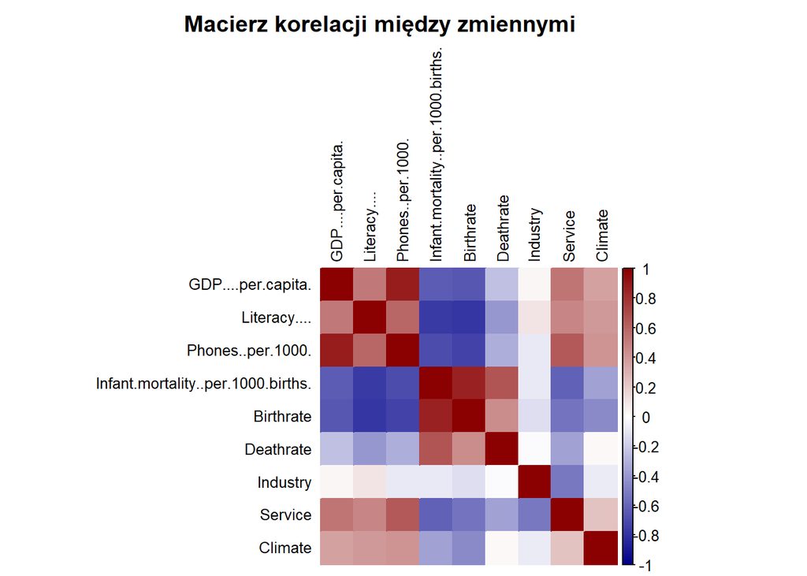

```r
if (!require(corrplot)) install.packages("corrplot")
library(corrplot)

corrplot(macierz_korelacji,
method = "color",
tl.cex = 0.8,
tl.col = "black",
col = colorRampPalette(c("darkblue", "white", "darkred"))(200),
cl.cex = 0.8,
cl.pos = "r",
mar = c(0,0,2,2),
title = "Macierz korelacji między zmiennymi")
```

Legenda kolorów:

| Kolor | Znaczenie |
| --- | --- |
| Ciemnoniebieski | silna ujemna korelacja (wartości bliskie -1) – gdy jedna zmienna rośnie, druga maleje. |
| Biały / jasny | brak korelacji (wartości bliskie 0) – zmienne niezależne. |
| Ciemnoczerwony | silna dodatnia korelacja (wartości bliskie +1) – gdy jedna zmienna rośnie, druga także. |

W analizie korelacji zaobserwowano silne dodatnie zależności pomiędzy zmiennymi ekonomicznymi (PKB, alfabetyzacja, liczba telefonów), co potwierdza, że rozwój gospodarczy wiąże się z wyższym poziomem edukacji i dostępem do infrastruktury. Jednocześnie występują silne ujemne korelacje z wskaźnikami demograficznymi (urodzenia, śmiertelność niemowląt), charakterystyczne dla krajów o niższym poziomie rozwoju. Zmienna „Climate” ma niewielki wpływ na te relacje. Zróżnicowany poziom korelacji wskazuje, że zestaw zmiennych jest dobrze dopasowany do dalszych analiz porządkowania liniowego i skupień.

## 2.10 Zapis oczyszczonych i wystandaryzowanych danych

```r
write.csv(as.data.frame(dane_stand), "countries_clean_scaled.csv", row.names = FALSE)
```

## 2.11 Wnioski z Etapu II

Dane są odpowiednio przygotowane do dalszych etapów projektu. Większość zmiennych wykazuje znaczną zmienność (CV > 0,3), co oznacza, że mogą być użyte do porządkowania liniowego i analizy skupień. Występują silne korelacje między zmiennymi ekonomicznymi (PKB, liczba telefonów, alfabetyzacja), co wskazuje na powiązania między rozwojem gospodarczym a poziomem infrastruktury i edukacji. Zmienna „Climate” wykazuje słabsze zależności, co sugeruje mniejsze znaczenie czynników środowiskowych.

# 3 ETAP III: Porządkowanie liniowe – ocena poziomu rozwoju krajów

Celem tego etapu jest utworzenie rankingu krajów świata na podstawie wybranych zmiennych społeczno-ekonomicznych. Wykorzystane zostaną dwie metody: bezwzorcowa i wzorcowa (metoda Hellwiga).

## 3.1 Metoda wzorcowa i bezwzorcowa

- Metoda bezwzorcowa – tworzy ranking krajów na podstawie średniej ze standaryzowanych wskaźników (czyli mają średnią 0 i odchylenie 1). Im wyższa wartość, tym kraj bardziej rozwinięty.
- Metoda wzorcowa (Hellwiga) – porównuje każdy kraj z „krajem idealnym” mającym najlepsze wartości wszystkich cech. Im bliżej wzorca (większy wynik), tym wyższy poziom rozwoju.

## 3.2 Przygotowanie danych do porządkowania liniowego

Stymulanty to zmienne, dla których wyższe wartości oznaczają lepszy poziom rozwoju (np. PKB, alfabetyzacja), a destymulanty – takie, gdzie wyższe wartości są niekorzystne (np. śmiertelność niemowląt). Aby umożliwić wspólne porównanie, destymulanty zostały przekształcone na stymulanty przez zmianę znaku.

```r
# Użycie wystandaryzowanych danych z etapu II
dane_lin <- as.data.frame(dane_stand)
```

```r
# Określenie stymulant (im więcej, tym lepiej)
stymulanty <- c("GDP....per.capita.", "Literacy....", "Phones..per.1000.",
                "Industry", "Service", "Climate")
```

```r
# Określenie destymulant (im więcej, tym gorzej)
destymulanty <- c("Infant.mortality..per.1000.births.", "Birthrate", "Deathrate")
```

```r
# Zamiana destymulant na stymulanty (mnożenie przez -1)
dane_lin[destymulanty] <- dane_lin[destymulanty] * (-1)
```

## 3.3 Metoda bezwzorcowa

```r
# Miernik syntetyczny = średnia arytmetyczna wystandaryzowanych wartości

dane_lin$miara_bezwzorcowa <- apply(dane_lin, 1, mean)

# Ranking krajów

ranking_bez <- dane_lin[order(-dane_lin$miara_bezwzorcowa), "miara_bezwzorcowa"]
head(ranking_bez)
```

```
## [1] 1.226192 1.145269 1.121632 1.116311 1.063769 1.045544
```

Najwyższe wartości miary bezwzorcowej (ok. 1.2) mają kraje wysoko rozwinięte, z wysokim PKB, dobrą edukacją i niską śmiertelnością niemowląt. Niższe wartości oznaczają kraje słabiej rozwinięte. Miara pokazuje ogólny poziom rozwoju, im wyższa, tym lepiej.

## 3.4 Metoda wzorcowa (Hellwiga)

```r
# Wyznaczenie wzorca – maksymalne wartości zmiennych

wzorzec <- apply(dane_lin[, zmienne], 2, max)

# Obliczenie odległości euklidesowej od wzorca

distanse <- apply(dane_lin[, zmienne], 1, function(x) sqrt(sum((wzorzec - x)^2)))

# Wyznaczenie miernika Hellwiga

d0 <- mean(distanse) + 2 * sd(distanse)
miara_wzorcowa <- 1 - (distanse / d0)
miara_wzorcowa[miara_wzorcowa < 0] <- 0

# Dodanie do ramki danych

dane_lin$miara_wzorcowa <- miara_wzorcowa

# Ranking wg metody Hellwiga

ranking_wz <- dane_lin[order(-dane_lin$miara_wzorcowa), "miara_wzorcowa"]
head(ranking_wz)
```

```
## [1] 0.5606549 0.5587397 0.5477763 0.5452539 0.5271279 0.5248385
```

Najwyższe wartości miernika Hellwiga (ok. 0.56) uzyskały kraje najlepiej rozwinięte, o wysokim PKB, dobrej edukacji i niskiej śmiertelności niemowląt. Niższe wartości oznaczają kraje słabiej rozwinięte, bardziej oddalone od wzorca. Metoda Hellwiga potwierdza wyniki metody bezwzorcowej, ranking krajów jest bardzo podobny.

## 3.5 Porównanie metod i korelacja rankingów

```r
# Korelacja między rankingami

cor(dane_lin$miara_bezwzorcowa, dane_lin$miara_wzorcowa)
```

```
## [1] 0.9804826
```

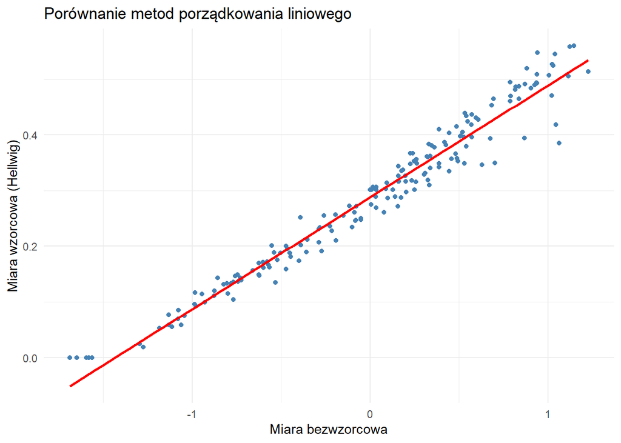

```r
# Wykres porównawczy

if(!require(ggplot2)) install.packages("ggplot2")
library(ggplot2)

ggplot(dane_lin, aes(x = miara_bezwzorcowa, y = miara_wzorcowa)) +
geom_point(color = "steelblue") +
geom_smooth(method = "lm", se = FALSE, color = "red") +
labs(title = "Porównanie metod porządkowania liniowego",
x = "Miara bezwzorcowa",
y = "Miara wzorcowa (Hellwig)") +
theme_minimal()
```

## 3.6 Wnioski z porządkowania liniowego

Obie metody dają bardzo zbliżone wyniki, punkty na wykresie leżą blisko linii trendu, a korelacja między miarami wynosi 0.9804826 (≈ 0,98). Oznacza to, że zarówno metoda bezwzorcowa, jak i metoda wzorcowa Hellwiga porządkują kraje w podobny sposób, co świadczy o spójności i stabilności wyników.

Niewielkie różnice wynikają z faktu, że metoda Hellwiga dodatkowo uwzględnia odległość od wzorca idealnego, przez co lepiej różnicuje kraje o średnim poziomie rozwoju.

Wysoka korelacja między metodami potwierdza, że dane są dobrze dobrane, a obie metody opisują to samo zjawisko: poziom rozwoju społeczno-gospodarczego państw. Dzięki temu można uznać, że uzyskane rankingi są wiarygodne i możliwe do dalszej interpretacji w kolejnych etapach projektu.

# 4 ETAP IV: Analiza skupień (klasteryzacja)

## 4.2 Przygotowanie danych

```r
dane_cluster <- as.data.frame(dane_stand)
```

## 4.3 Dobór liczby skupień (metoda łokcia)

Metoda łokcia pozwala określić optymalną liczbę grup poprzez analizę spadku wariancji wewnątrz skupień. Optymalna liczba k odpowiada punktowi, w którym dalsze zwiększanie liczby grup nie przynosi znaczącej poprawy.

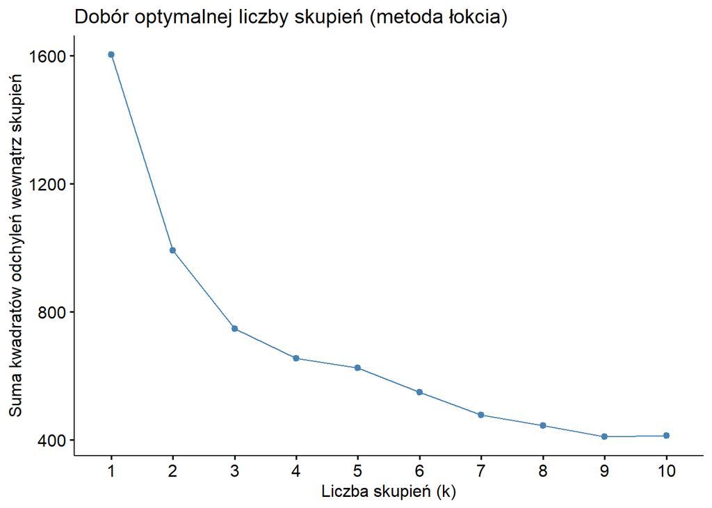

```r
if(!require(factoextra)) install.packages("factoextra")
library(factoextra)

fviz_nbclust(dane_cluster, kmeans, method = "wss") +
labs(title = "Dobór optymalnej liczby skupień (metoda łokcia)",
x = "Liczba skupień (k)",
y = "Suma kwadratów odchyleń wewnątrz skupień")
```

Na wykresie widać, że wraz ze wzrostem liczby skupień (k) suma kwadratów odchyleń wewnątrz grup (WSS) maleje, oznacza to, że podział danych staje się coraz dokładniejszy. Jednak po wartości k = 4 tempo spadku wyraźnie się spowalnia. Krzywa “zagina się”, tworząc “łokieć”.

Na podstawie wykresu łokcia mozna uznać że k = 4 to optymalna liczba skupień. Oznacza to, że dane najlepiej opisują cztery wyraźne grupy krajów o różnym poziomie rozwoju społeczno-gospodarczego.

## 4.4 Metoda podziałowa – k-means

Metoda k-means dzieli kraje na k grup tak, aby w każdej znalazły się państwa najbardziej do siebie podobne, a różnice między grupami były jak największe.

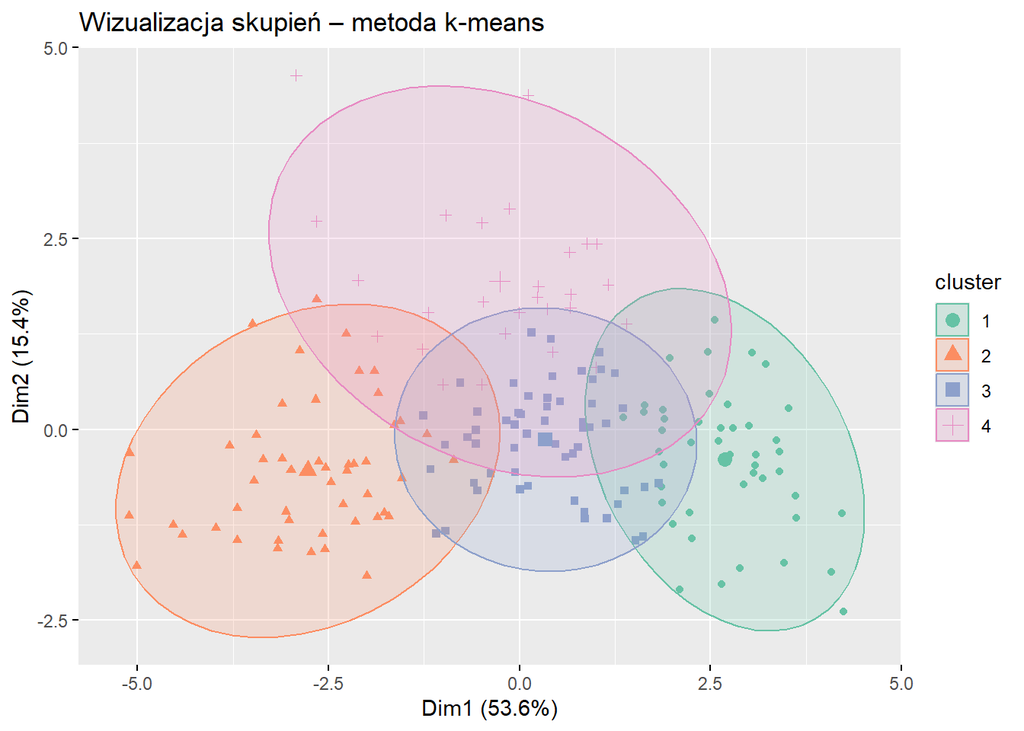

```r
set.seed(123)
kmeans_model <- kmeans(dane_cluster, centers = 4, nstart = 25)

fviz_cluster(kmeans_model, data = dane_cluster,
main = "Wizualizacja skupień – metoda k-means",
geom = "point",
ellipse.type = "norm",
palette = "Set2")
```

## 4.5 Metoda hierarchiczna – Ward

Metoda hierarchiczna (Ward) tworzy skupienia stopniowo, łącząc najbardziej podobne jednostki w większe grupy.

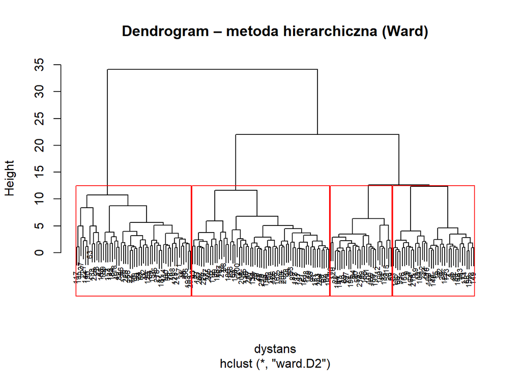

```r
dystans <- dist(dane_cluster, method = "euclidean")
hclust_model <- hclust(dystans, method = "ward.D2")

plot(hclust_model, main = "Dendrogram – metoda hierarchiczna (Ward)", cex = 0.6)
rect.hclust(hclust_model, k = 4, border = "red")
```

Dendrogram przedstawia proces łączenia krajów w coraz większe grupy na podstawie ich podobieństwa. Na osi pionowej (Height) widoczny jest poziom różnic między skupieniami: im wyżej połączenie, tym większe różnice między grupami.

## 4.6 Przypisanie krajów do grup i porównanie metod

```r
grupy_hier <- cutree(hclust_model, k = 4)
table(grupy_hier)
```

```
## grupy_hier
##  1  2  3  4
## 52 62 37 28
```

```r
table(kmeans_model$cluster, grupy_hier)
```

```
##    grupy_hier
##      1  2  3  4
##   1  0  0 18 28
##   2 48  1  0  0
##   3  1 39 17  0
##   4  3 22  2  0
```

```r
grupy_hier <- cutree(hclust_model, k = 4)
table(grupy_hier)
```

```
## grupy_hier
##  1  2  3  4
## 52 62 37 28
```

```r
table(kmeans_model$cluster, grupy_hier)
```

```
##    grupy_hier
##      1  2  3  4
##   1  0  0 18 28
##   2 48  1  0  0
##   3  1 39 17  0
##   4  3 22  2  0
```

## 4.8 Wnioski z analizy skupień

W analizie skupień zastosowano dwie metody: k-means i hierarchiczną (Ward). Celem było pogrupowanie krajów o podobnym poziomie rozwoju społeczno-gospodarczego.

Dobór liczby skupień (metoda łokcia): Na wykresie „łokcia” widać, że spadek wariancji wewnątrz grup znacząco zwalnia po k = 4, co wskazuje, że cztery klastry są optymalnym podziałem danych.

# 5 ETAP V: Podsumowanie i interpretacja wyników

Celem projektu było porównanie krajów świata pod względem poziomu rozwoju społeczno-gospodarczego z wykorzystaniem dwóch metod analizy wielowymiarowej: porządkowania liniowego oraz analizy skupień.

W projekcie wykorzystano dane z pliku countries of the world.csv, zawierające wskaźniki takie jak: PKB per capita, alfabetyzacja, liczba telefonów, śmiertelność niemowląt, przyrost naturalny, udział przemysłu i usług w PKB oraz klimat. Dane zostały oczyszczone, wystandaryzowane i poddane dalszej analizie.

## 5.1 Wyniki porządkowania liniowego

W ramach porządkowania liniowego zastosowano dwie metody:

- Metodę bezwzorcową (średnia ze znormalizowanych wartości).
- Metodę wzorcową (Hellwiga), która porównuje każdy kraj z krajem “idealnym”.

Obie metody dały bardzo zbliżone wyniki: współczynnik korelacji między rankingami wyniósł 0,98, co wskazuje na wysoką zgodność ocen. Najwyższe pozycje w rankingu zajęły kraje wysoko rozwinięte (o wysokim PKB, wysokiej alfabetyzacji i niskiej śmiertelności niemowląt), natomiast na końcu znalazły się kraje rozwijające się i najsłabiej rozwinięte.

Metoda Hellwiga pozwoliła nieco lepiej różnicować kraje o średnim poziomie rozwoju, dzięki uwzględnieniu odległości od wzorca.

## 5.2 Wyniki analizy skupień

Zastosowano dwie metody grupowania:

- k-means (metoda podziałowa).
- metodę hierarchiczną (Ward).

## 5.4 Wnioski końcowe

- Zastosowane metody umożliwiły ocenę i klasyfikację krajów pod względem poziomu rozwoju społeczno-gospodarczego.
- Obie techniki porządkowania liniowego (bezwzorcowa i Hellwiga) dały zbieżne wyniki, co świadczy o ich wiarygodności.
- Analiza skupień potwierdziła istnienie czterech głównych grup krajów, zróżnicowanych pod względem badanych cech.
- Wyniki obu podejść są spójne – kraje wysoko rozwinięte osiągały najwyższe wartości miar syntetycznych i jednocześnie tworzyły odrębny klaster.
- Projekt potwierdził, że dane społeczno-gospodarcze w sposób czytelny odzwierciedlają globalne różnice w poziomie rozwoju i mogą być skutecznie analizowane z wykorzystaniem metod statystycznych.

## 5.5 Zakończenie

Przeprowadzona analiza pokazała, że metody statystyczne, takie jak porządkowanie liniowe i analiza skupień, pozwalają w sposób przejrzysty i obiektywny klasyfikować kraje świata według poziomu rozwoju. Wyniki uzyskane różnymi podejściami są spójne, co potwierdza ich rzetelność. Projekt stanowi przykład praktycznego zastosowania metod ilościowych w analizie zjawisk społeczno-gospodarczych i może być podstawą do dalszych badań nad rozwojem krajów.